# Working Directories

Simon J. Kiss

# 1 Working directories

Your *working directory* is the folder on your computer in which you are currently working. When you ask R to open a certain file, it will look in the working directory for this file, and when you tell R to save a data file or figure, it will save it in the working directory.

When you open up RStudio - without opening up a `.rproj` file (e.g. a project), the default working directory is your home directory on your computer. You can tell what your working directory is by running the command `getwd()` either in the console or in the R script.

Try it.

Open up RStudio *without openening an `.Rproj` file or a project and run `getwd()` and see what you get. I get this:

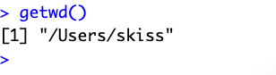

Working directories can be *changed* with the commmand `setwd()`. I’m going to set mine to be my `Documents` folder on my hard drive. You try it too. This will have to change depending on what your general documetns folder is called and whether or not you work on a Mac or a PC. But give it a try.

```r
#Set the working directory
setwd("~/Documents")
#Check to see if it worked
getwd()
```

```
## [1] "/Users/skiss/Documents"
```

OK, so far so good.

However, this is ultimately unsatisfying for a very simple reason. Everyone’s computer is different. PCs home directories start with `c:/` and Mac home directories start with `Users/user_name`. Also, people download packages of files we are working and might not store them in `Documents` . It might be called `My documents`. This is going to be a problem in this way.

Look in the folder that this lesson is located. Check to make sure that you are *not* in a project and that the working directory is somewhere other than this folder.

But select `File > Open File` and navigate to the file in the folder `Working_Directories` called `import.R`.

Open it and run the script, line-by-line or top-to-bottom. You should see this error:

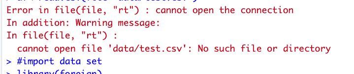

The reason is that R is starting in the working directory returned by `getwd()` and adding the path name `data/test.csv` to and it’s not finding it, because *it is not there*.

Now, we could modify `import.R` by putting a `setwd()` command at the top but this presents a problem. When we are sharing our work with others, we *have no idea what their computer folder structre looks like!* Is it a Mac? Or a PC? Have they saved their folders on the desktop? Or in their `Documents` folder?

For an amusing description of this problem, please see this [page](https://github.com/jennybc/here_here).

There are very easy practical solutions to this problem. The first is to *always* - and I do mean *always* - think and work in terms of `RStudio` projects. These are defined by files that end in `.rproj`. Usually I define one project per analysis.

### 1.0.1 Projects

An RStudio project is a particular type of file, with the extension `.rproj` that does a few things, but mostly, all it does is it automatically sets the working directory to be **wherever the `.Rproj` folder is.**

You can open RStudio projects by select `File > Open Project` or by double-clicking an `.rproj` file.

Let’s see what happens.

Start by running `getwd()` and make note of where you are. Check to see if you are in an RStudio project by looking in the top-right of the RStudio panel. Hopefully it says `Project: None`.

[figure not shown]

Now, select `File > Open Project` and navigate to the folder where this lesson is located and open the file. Open `Working_Directories.Rproj`.

Now, look again at the top right. You should see this.

[figure not shown]

and now, the *pièce de résistance*, open the file `import.R` and run the script from top to bottom.

I’m going to guess you successfully have imported a little fake data frame containing information on age and vote choice.

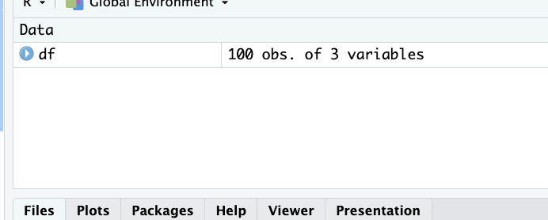

What I can do with this, is I can send a link to this folder via `OneDrive`, or host it on Github, or zip it up and e-mail it to someone and *as long as they open the `.rproj` file to get into the proper working directory, the script will work in exactly the same way.

## 1.1 The `here()` package.

The `here()` package is a next-level improvement on this problem and I insist we use it as much as possible. If you have not installed it, please do so and then load it.

The `here` package provides just the `here()` command. Run it and see what it does.

```
## [1] "/Users/skiss/Library/CloudStorage/OneDrive-WilfridLaurierUniversity/Courses/RLISPOP/Working_Directories"
```

Essentially, it creates an `absolute path name` starting with *your* root directory down to the working directory of the project you are in.

Now try to combine `here()` with a subfolder name in our folder. But the amazing thing is, when *I* open up and run `here()` on my computer, `here()` will generate a path name that is appropriate to *my computer*. But then when I e-mail you the package of files to work on, it will generate a pathname that is appropriate to *your* computer.

```
## [1] "/Users/skiss/Library/CloudStorage/OneDrive-WilfridLaurierUniversity/Courses/RLISPOP/Working_Directories/data"
```

### 1.1.1 Organized folders

A final note on keeping your folders organized. It is not *necessary* but it is *highly* desirable to organize the folders in your workspaces carefully and logically. Coding can get messy very quickly.

You *should* get in the habit of maintaining clear folders for all the different types of material your project will entail.

At a minimum, there should be one subfolder for your data and one sub-folder for your graphs.